# DS6372 Project 1

Caleb Thornsbury, Stephanie Duarte, Steven Cox

2024-02-02

## Life Expectancy Data Set

```r
life_orig <- read.csv("Data/Life_Expectancy_Data.csv")
summary(life_orig)
```

```
##    Country               Year         Status          Life.expectancy
##  Length:2938        Min.   :2000   Length:2938        Min.   :36.30
##  Class :character   1st Qu.:2004   Class :character   1st Qu.:63.10
##  Mode  :character   Median :2008   Mode  :character   Median :72.10
##                     Mean   :2008                      Mean   :69.22
##                     3rd Qu.:2012                      3rd Qu.:75.70
##                     Max.   :2015                      Max.   :89.00
##                                                       NA's   :10
##  Adult.Mortality infant.deaths       Alcohol        percentage.expenditure
##  Min.   :  1.0   Min.   :   0.0   Min.   : 0.0100   Min.   :    0.000
##  1st Qu.: 74.0   1st Qu.:   0.0   1st Qu.: 0.8775   1st Qu.:    4.685
##  Median :144.0   Median :   3.0   Median : 3.7550   Median :   64.913
##  Mean   :164.8   Mean   :  30.3   Mean   : 4.6029   Mean   :  738.251
##  3rd Qu.:228.0   3rd Qu.:  22.0   3rd Qu.: 7.7025   3rd Qu.:  441.534
##  Max.   :723.0   Max.   :1800.0   Max.   :17.8700   Max.   :19479.912
##  NA's   :10                       NA's   :194
##   Hepatitis.B       Measles              BMI        under.five.deaths
##  Min.   : 1.00   Min.   :     0.0   Min.   : 1.00   Min.   :   0.00
##  1st Qu.:77.00   1st Qu.:     0.0   1st Qu.:19.30   1st Qu.:   0.00
##  Median :92.00   Median :    17.0   Median :43.50   Median :   4.00
##  Mean   :80.94   Mean   :  2419.6   Mean   :38.32   Mean   :  42.04
##  3rd Qu.:97.00   3rd Qu.:   360.2   3rd Qu.:56.20   3rd Qu.:  28.00
##  Max.   :99.00   Max.   :212183.0   Max.   :87.30   Max.   :2500.00
##  NA's   :553                        NA's   :34
##      Polio       Total.expenditure   Diphtheria       HIV.AIDS
##  Min.   : 3.00   Min.   : 0.370    Min.   : 2.00   Min.   : 0.100
##  1st Qu.:78.00   1st Qu.: 4.260    1st Qu.:78.00   1st Qu.: 0.100
##  Median :93.00   Median : 5.755    Median :93.00   Median : 0.100
##  Mean   :82.55   Mean   : 5.938    Mean   :82.32   Mean   : 1.742
##  3rd Qu.:97.00   3rd Qu.: 7.492    3rd Qu.:97.00   3rd Qu.: 0.800
##  Max.   :99.00   Max.   :17.600    Max.   :99.00   Max.   :50.600
##  NA's   :19      NA's   :226       NA's   :19
##       GDP              Population        thinness..1.19.years
##  Min.   :     1.68   Min.   :3.400e+01   Min.   : 0.10
##  1st Qu.:   463.94   1st Qu.:1.958e+05   1st Qu.: 1.60
##  Median :  1766.95   Median :1.387e+06   Median : 3.30
##  Mean   :  7483.16   Mean   :1.275e+07   Mean   : 4.84
##  3rd Qu.:  5910.81   3rd Qu.:7.420e+06   3rd Qu.: 7.20
##  Max.   :119172.74   Max.   :1.294e+09   Max.   :27.70
##  NA's   :448         NA's   :652         NA's   :34
##  thinness.5.9.years Income.composition.of.resources   Schooling
##  Min.   : 0.10      Min.   :0.0000                  Min.   : 0.00
##  1st Qu.: 1.50      1st Qu.:0.4930                  1st Qu.:10.10
##  Median : 3.30      Median :0.6770                  Median :12.30
##  Mean   : 4.87      Mean   :0.6276                  Mean   :11.99
##  3rd Qu.: 7.20      3rd Qu.:0.7790                  3rd Qu.:14.30
##  Max.   :28.60      Max.   :0.9480                  Max.   :20.70
##  NA's   :34         NA's   :167                     NA's   :163
```

```r
sapply(life_orig, class)
```

```
##                         Country                            Year
##                     "character"                       "integer"
##                          Status                 Life.expectancy
##                     "character"                       "numeric"
##                 Adult.Mortality                   infant.deaths
##                       "integer"                       "integer"
##                         Alcohol          percentage.expenditure
##                       "numeric"                       "numeric"
##                     Hepatitis.B                         Measles
##                       "integer"                       "integer"
##                             BMI               under.five.deaths
##                       "numeric"                       "integer"
##                           Polio               Total.expenditure
##                       "integer"                       "numeric"
##                      Diphtheria                        HIV.AIDS
##                       "integer"                       "numeric"
##                             GDP                      Population
##                       "numeric"                       "numeric"
##            thinness..1.19.years              thinness.5.9.years
##                       "numeric"                       "numeric"
## Income.composition.of.resources                       Schooling
##                       "numeric"                       "numeric"
```

## Preliminary Data Wrangling

Explanatory variable is Life.expectancy. Therefore, before starting the EDA, any rows missing the explanatory variable will be filtered out.

```r
missing_life_expectancy <- life_orig %>% select(Life.expectancy) %>% sapply(function(x) sum(is.na(x)))
print(missing_life_expectancy)
```

```
## Life.expectancy
##              10
```

```r
#Remove all rows that have missing values of our explanatory variable Life.expectancy
life <- life_orig %>%
  filter(!is.na(Life.expectancy))

# To see the first few rows of the filtered data frame
head(life)
```

```
##       Country Year     Status Life.expectancy Adult.Mortality infant.deaths
## 1 Afghanistan 2015 Developing            65.0             263            62
## 2 Afghanistan 2014 Developing            59.9             271            64
## 3 Afghanistan 2013 Developing            59.9             268            66
## 4 Afghanistan 2012 Developing            59.5             272            69
## 5 Afghanistan 2011 Developing            59.2             275            71
## 6 Afghanistan 2010 Developing            58.8             279            74
##   Alcohol percentage.expenditure Hepatitis.B Measles  BMI under.five.deaths
## 1    0.01              71.279624          65    1154 19.1                83
## 2    0.01              73.523582          62     492 18.6                86
## 3    0.01              73.219243          64     430 18.1                89
## 4    0.01              78.184215          67    2787 17.6                93
## 5    0.01               7.097109          68    3013 17.2                97
## 6    0.01              79.679367          66    1989 16.7               102
##   Polio Total.expenditure Diphtheria HIV.AIDS       GDP Population
```

[output cut: 20 more lines]

### Missing and NA Analysis

```r
sapply(life, function(x) sum(is.na(x)))
```

```
##                         Country                            Year
##                               0                               0
##                          Status                 Life.expectancy
##                               0                               0
##                 Adult.Mortality                   infant.deaths
##                               0                               0
##                         Alcohol          percentage.expenditure
##                             193                               0
##                     Hepatitis.B                         Measles
##                             553                               0
##                             BMI               under.five.deaths
##                              32                               0
##                           Polio               Total.expenditure
##                              19                             226
##                      Diphtheria                        HIV.AIDS
##                              19                               0
##                             GDP                      Population
##                             443                             644
##            thinness..1.19.years              thinness.5.9.years
##                              32                              32
## Income.composition.of.resources                       Schooling
##                             160                             160
```

```r
missing_count <- life %>% select(-Life.expectancy) %>% sapply(function(x) sum(is.na(x)))
missing_table <- as.data.frame(missing_count) %>%
  filter(missing_count >= 1) %>% arrange(desc(missing_count))
print(missing_table)
```

```
##                                 missing_count
## Population                                644
## Hepatitis.B                               553
## GDP                                       443
## Total.expenditure                         226
## Alcohol                                   193
## Income.composition.of.resources           160
## Schooling                                 160
## BMI                                        32
## thinness..1.19.years                       32
## thinness.5.9.years                         32
## Polio                                      19
## Diphtheria                                 19
```

```r
# Sort data frame by the number of missing values
# Adding an ID column to dataframe
life$ID <- 1:nrow(life)

# Create a table of number of missing values per observation
MissingCount = rowSums(is.na(life))
missing_values_summary <- data.frame(ID = life$ID, MissingCount = MissingCount)
missing_values_summary <- missing_values_summary[order(-missing_values_summary$MissingCount), ]
head(missing_values_summary)
```

```
##        ID MissingCount
## 2409 2409            9
## 2410 2410            9
## 2411 2411            9
## 2412 2412            9
## 2413 2413            9
## 2414 2414            9
```

# Objective 1

Purpose: Display the ability to build regression models using the skills and discussions from Unit 1, 2, and 3 with the purpose of identifying key relationships and interpreting those relationships in an organized and clear fashion (Unit 4) .

## EDA

### Distribution of Status

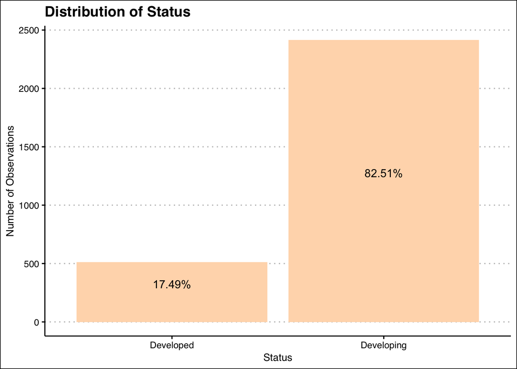

```r
# Calculate counts and percentages
summary_df <- life %>%
  group_by(Status) %>%
  summarise(count = n()) %>%
  mutate(percentage = round(count / sum(count) * 100, 2),
         label = paste0(percentage, "%")) %>%
  ungroup()

# Visualize the distribution of Status with percentages
ggplot(life, aes(x = Status)) +
  geom_bar(fill = "peachpuff", aes(y = ..count..)) + # Use ..count.. to get the count for each bar
  geom_text(data = summary_df, aes(x = Status, y = count/2, label = label), position = position_dodge(width = 0.9), vjust = -0.5) +
  theme_clean() +
  labs(title = "Distribution of Status", x = "Status", y = "Number of Observations")
```

```r
# life$Status_dummy <- ifelse(life$Status == "Developing", 1, 0)
```

Developed 512 17.5% , Developing 2416 82.5%.

### Number of observations per Country

```r
## Create a table with number of observations
print(table(life$Country))
```

```
##
##                                          Afghanistan
##                                                   16
##                                              Albania
##                                                   16
##                                              Algeria
##                                                   16
##                                               Angola
##                                                   16
##                                  Antigua and Barbuda
##                                                   16
##                                            Argentina
##                                                   16
##                                              Armenia
##                                                   16
##                                            Australia
##                                                   16
##                                              Austria
##                                                   16
##                                           Azerbaijan
##                                                   16
##                                              Bahamas
##                                                   16
##                                              Bahrain
##                                                   16
##                                           Bangladesh
##                                                   16
##                                             Barbados
##                                                   16
##                                              Belarus
##                                                   16
##                                              Belgium
##                                                   16
##                                               Belize
##                                                   16
##                                                Benin
##                                                   16
##                                               Bhutan
##                                                   16
##                     Bolivia (Plurinational State of)
```

[output cut: 312 more lines]

```
##                                                   16
##                                           Uzbekistan
##                                                   16
##                                              Vanuatu
##                                                   16
##                   Venezuela (Bolivarian Republic of)
##                                                   16
##                                             Viet Nam
##                                                   16
##                                                Yemen
##                                                   16
##                                               Zambia
##                                                   16
##                                             Zimbabwe
##                                                   16
```

- All of the countries have the same number of observations, 16.

### Visualize Life Expectancy over the Years

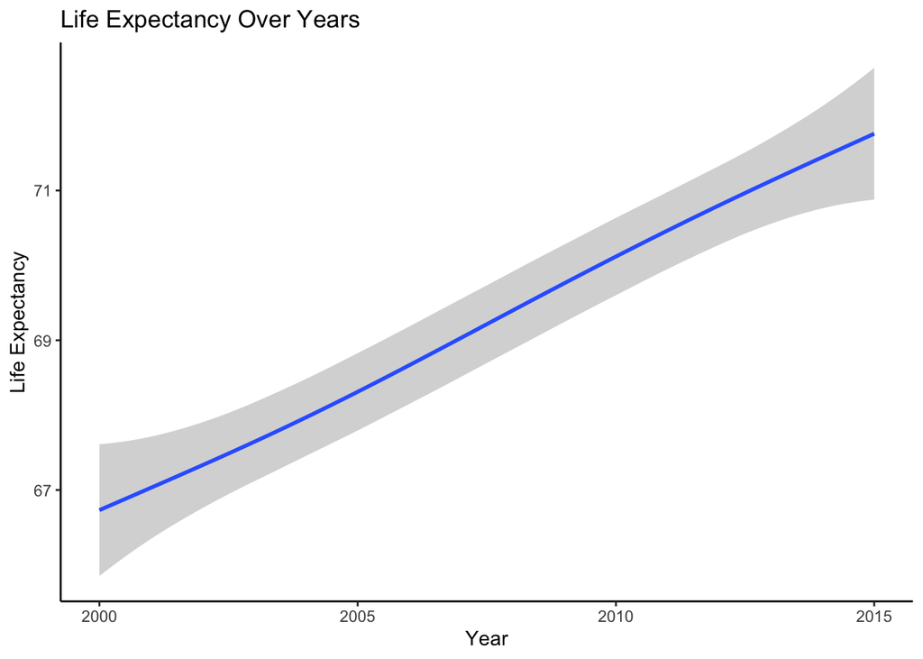

```r
ggplot(life, aes(x = Year, y = Life.expectancy)) +
  geom_smooth() +
  theme_classic() +
  labs(title = "Life Expectancy Over Years",
       x = "Year",
       y = "Life Expectancy")
```

### Visualize Life Expectancy over the Years by Region

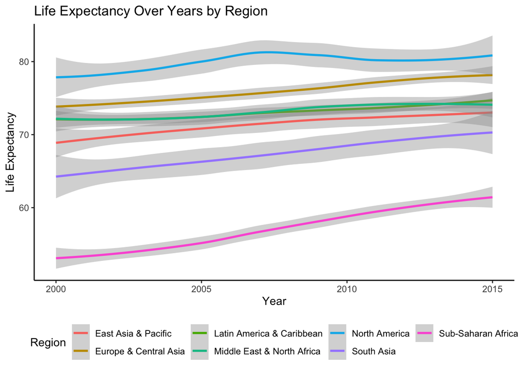

```r
# Use the countrycode package to break up the Countries by Region
life$Region <- as.factor(countrycode(life$Country, "country.name", "region"))

ggplot(life, aes(x = Year, y = Life.expectancy, group = Region, color = Region)) +
  geom_smooth() +
  theme_classic() +
  labs(title = "Life Expectancy Over Years by Region",
       x = "Year",
       y = "Life Expectancy") +
  theme(legend.position = "bottom")
```

There is definitely a trend to consider when considering life expectancy based on which region the person is from. Might consider using a dummy variable to break up region numerically for modeling.

### Checking correlation and variance.

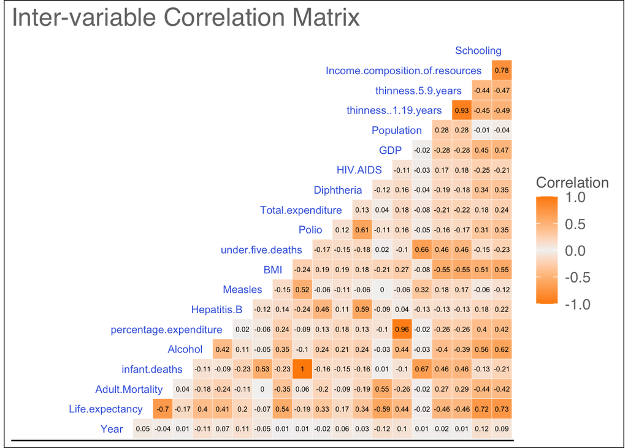

```r
p <- life %>%
  select(where(is.numeric), -ID) %>%
  na.omit() %>%
  ggcorr(
    label = TRUE,
    label_size = 2,
    label_round = 2,
    hjust = 1,
    size = 3,
    color = "royalblue",
    layout.exp = 5,
    low = "darkorange",
    mid = "gray95",
    high = "darkorange",
    name = "Correlation"
  )
p + ggtitle("Inter-variable Correlation Matrix ") + theme_gdocs()
```

```r
# Compute the correlation matrix
# correlations <- cor(life_numeric)
# life_expectancy_cor <- correlations["Life.expectancy", ]
# print(life_expectancy_cor)
```

Life Expectancy has a strong correlation with Adult Mortality, BMI, HIV/AIDS, Income Composition, Schooling. There is no evidence of a correlation with, Infant Deaths, Hepatitis B, Measles, Population, Total Expenditure, Under Five Deaths.

## Influential Points Analysis

```r
### Creating model
### This function is removing the columns Country and Year from the pureData data frame.
life_selected <- life %>% na.omit(life) %>%
                 select(-ID, -Country, -Year) %>%
                 mutate(`Hepatitis.B` = ifelse(`Hepatitis.B` < 90, "<90% Covered", ">=90% Covered"),
                        Polio = ifelse(Polio < 90, "<90% Covered", ">=90% Covered"),
                        Diphtheria = ifelse(Diphtheria < 90, "<90% Covered", ">=90% Covered"),
                        `Hepatitis.B` = as.factor(`Hepatitis.B`),
                        Polio = as.factor(Polio),
                        Diphtheria = as.factor(Diphtheria))

LEmodel <- lm(`Life.expectancy` ~ ., data = life_selected)
summary(LEmodel)
```

```
##
## Call:
## lm(formula = Life.expectancy ~ ., data = life_selected)
##
## Residuals:
##      Min       1Q   Median       3Q      Max
## -15.5955  -2.0522  -0.0404   1.9542  12.2938
##
## Coefficients:
##                                    Estimate Std. Error t value Pr(>|t|)
## (Intercept)                       5.882e+01  7.836e-01  75.065  < 2e-16 ***
## StatusDeveloping                 -1.748e+00  3.399e-01  -5.143 3.04e-07 ***
## Adult.Mortality                  -1.383e-02  8.901e-04 -15.537  < 2e-16 ***
## infant.deaths                     5.742e-02  1.016e-02   5.652 1.87e-08 ***
## Alcohol                          -9.411e-02  3.424e-02  -2.749 0.006049 **
## percentage.expenditure            2.809e-04  1.716e-04   1.637 0.101774
## Hepatitis.B>=90% Covered         -4.521e-01  2.904e-01  -1.557 0.119680
## Measles                           1.178e-05  1.014e-05   1.162 0.245557
## BMI                               6.043e-03  5.864e-03   1.031 0.302875
## under.five.deaths                -4.472e-02  7.329e-03  -6.102 1.31e-09 ***
## Polio>=90% Covered                3.568e-01  4.007e-01   0.890 0.373386
## Total.expenditure                -8.663e-03  3.881e-02  -0.223 0.823399
## Diphtheria>=90% Covered           6.294e-01  4.478e-01   1.405 0.160116
## HIV.AIDS                         -3.554e-01  1.739e-02 -20.436  < 2e-16 ***
## GDP                               2.586e-05  2.666e-05   0.970 0.332149
## Population                       -2.781e-10  1.615e-09  -0.172 0.863303
## thinness..1.19.years             -7.754e-02  5.276e-02  -1.470 0.141859
## thinness.5.9.years               -4.483e-02  4.904e-02  -0.914 0.360741
## Income.composition.of.resources   8.331e+00  7.758e-01  10.738  < 2e-16 ***
## Schooling                         7.871e-01  5.653e-02  13.925  < 2e-16 ***
## RegionEurope & Central Asia       8.933e-01  3.299e-01   2.708 0.006843 **
## RegionLatin America & Caribbean   2.481e+00  3.300e-01   7.517 9.19e-14 ***
## RegionMiddle East & North Africa  2.709e+00  3.925e-01   6.904 7.25e-12 ***
## RegionNorth America               3.749e+00  1.063e+00   3.528 0.000431 ***
## RegionSouth Asia                  2.566e+00  5.909e-01   4.343 1.49e-05 ***
## RegionSub-Saharan Africa         -2.429e+00  3.499e-01  -6.942 5.56e-12 ***
## ---
## Signif. codes:  0 '***' 0.001 '**' 0.01 '*' 0.05 '.' 0.1 ' ' 1
##
## Residual standard error: 3.298 on 1623 degrees of freedom
## Multiple R-squared:  0.8616, Adjusted R-squared:  0.8595
## F-statistic: 404.1 on 25 and 1623 DF,  p-value: < 2.2e-16
```

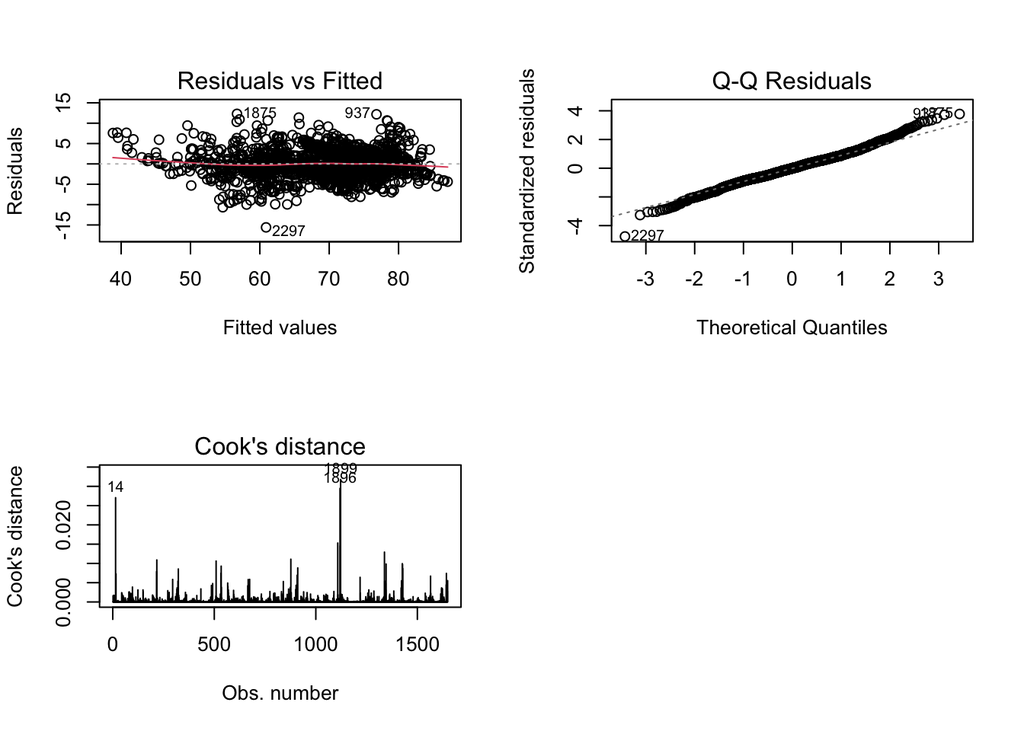

```r
# ols_plot_diagnostics(lm_model)

#Check the residuals
par(mfrow=c(2,2)) # Set up a 2x2 plot grid
plot(LEmodel, which = 1) # Residuals vs Fitted
plot(LEmodel, which = 2) # Normal Q-Q
plot(LEmodel, which = 4) # Cook's distance
par(mfrow = c(1, 1)) # Set up a 1x1 plot grid
```

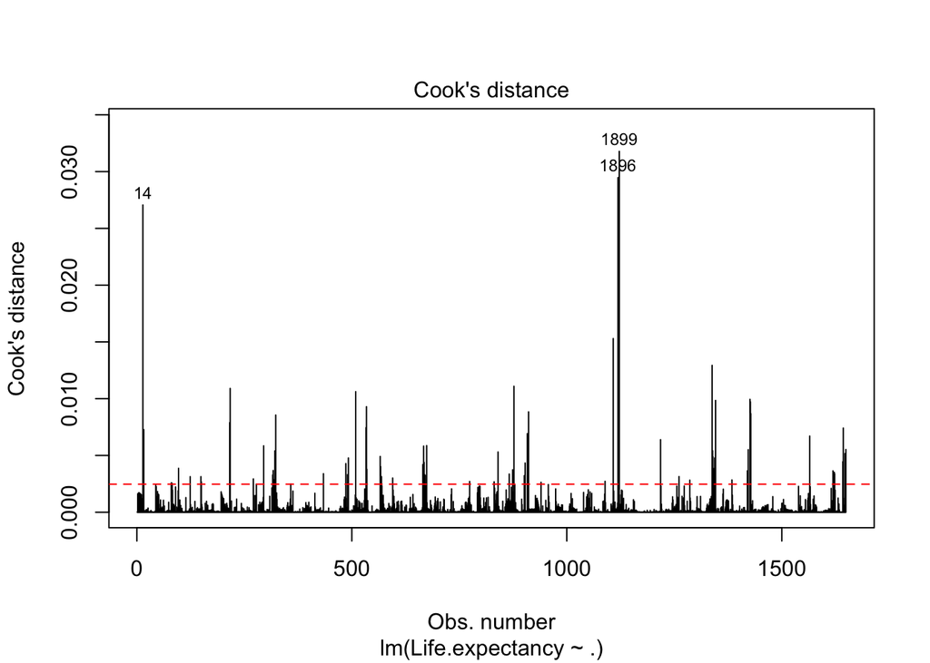

```r
cutoff <- 4/(nrow(life_selected)-length(LEmodel$coefficients)-2)
plot(LEmodel, which=4, cook.levels=cutoff)
abline(h=cutoff, lty=2, col="red")
```

## Final Basic Linear Regression Model

### Split the Dataset

Splitting up the data into a training and testing set so that we can compare the different models using the same data.

```r
#training and test set 80/20 split
set.seed(1234)
trainIndex <- createDataPartition(life_selected$`Life.expectancy`, p = .80, list = FALSE)
train <- life_selected[trainIndex, ]
test <- life_selected[-trainIndex, ]
```

```r
model_train <- lm(`Life.expectancy` ~ ., data = train)
# Predictions and Evaluation
predictions <- predict(model_train, newdata = test)
rmse_value <- sqrt(mean((predictions - test$`Life.expectancy`)^2))
print(paste("Basic Modle RMSE:",rmse_value))
```

```
## [1] "Basic Modle RMSE: 3.4609957912682"
```

RMSE for the test set: 3.460996

# Objective 2

Purpose: This objective is to go through a process to compare multiple models with the goal of developing a model that can predict the best and do well on future data. *Use caret library to help ensure model comparisons are on a “apples to apples” level of comparison.

### Feature Selection

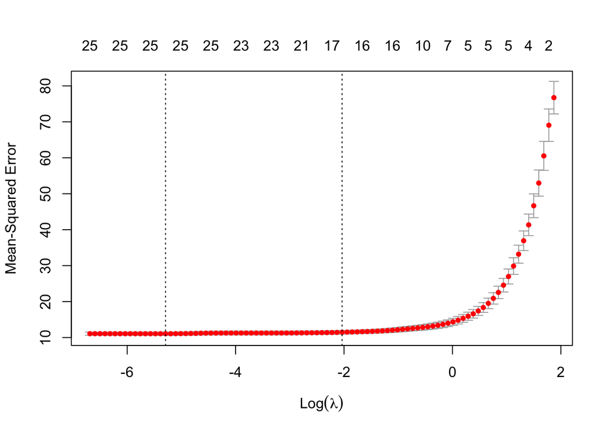

```r
# Add a marker to distinguish between train and test
train$dataset_type <- 'train'
test$dataset_type <- 'test'

# Combine the datasets
combined <- rbind(train, test)

# Apply model.matrix on the combined dataset
X_combined <- model.matrix(Life.expectancy ~ . - 1 - dataset_type, data = combined)  # Exclude the intercept and dataset_type

# Split the combined matrix back into training and testing sets
train_indices <- which(combined$dataset_type == 'train')
test_indices <- which(combined$dataset_type == 'test')

X_train <- X_combined[train_indices, ]
X_test <- X_combined[test_indices, ]

# Make sure to also create the response vector for training
y_train <- train$Life.expectancy
y_test <- test$Life.expectancy

set.seed(1234)
# Fit LASSO model using glmnet with alpha = 1 (LASSO)
cv_fit <- cv.glmnet(X_train, y_train, alpha = 1, nfolds = 5)
# Plot the cross-validated mean squared error for different values of lambda
plot(cv_fit)
```

```r
# Determine the minimal lambda
optimal_lambda <- cv_fit$lambda.min

coef_opt <- coef(cv_fit, s = optimal_lambda)
print(coef_opt)
```

```
## 27 x 1 sparse Matrix of class "dgCMatrix"
##                                             s1
## (Intercept)                       5.703706e+01
## StatusDeveloped                   1.644623e+00
## StatusDeveloping                  .
## Adult.Mortality                  -1.426414e-02
## infant.deaths                     4.008069e-02
## Alcohol                          -8.521500e-02
## percentage.expenditure            3.403833e-04
## Hepatitis.B>=90% Covered         -5.995058e-01
## Measles                           1.545092e-05
## BMI                               8.461129e-03
## under.five.deaths                -3.347466e-02
## Polio>=90% Covered                5.240788e-01
## Total.expenditure                -1.499867e-02
## Diphtheria>=90% Covered           6.036039e-01
## HIV.AIDS                         -3.231863e-01
## GDP                               1.641461e-05
## Population                        1.824434e-09
## thinness..1.19.years             -4.990142e-02
## thinness.5.9.years               -5.285524e-02
## Income.composition.of.resources   9.248583e+00
## Schooling                         7.480515e-01
## RegionEurope & Central Asia       5.609779e-01
## RegionLatin America & Caribbean   2.354444e+00
## RegionMiddle East & North Africa  2.408335e+00
## RegionNorth America               3.528801e+00
## RegionSouth Asia                  2.786607e+00
## RegionSub-Saharan Africa         -2.796348e+00
```

```r
# Fit model with optimal lambda
lasso_model <- glmnet(X_train, y_train, alpha = 1, lambda = optimal_lambda)

predictions <- predict(lasso_model, newx = X_test, s = optimal_lambda)

# Calculate RMSE on the test set
rmse_test <- sqrt(mean((predictions - y_test) ^ 2))
print(paste("Feature RMSE:", rmse_test))
```

```
## [1] "Feature RMSE: 3.43095260363838"
```

```r
set.seed(1234)
fitControl<-trainControl(method="repeatedcv",number=10,repeats=1)
glmnet.fit<-train(Life.expectancy~.,
               data=life_selected,
               method="glmnet",
               trControl=fitControl
               )
opt.pen<-glmnet.fit$finalModel$lambdaOpt
coef(glmnet.fit$finalModel,opt.pen)
```

```
## 26 x 1 sparse Matrix of class "dgCMatrix"
##                                             s1
## (Intercept)                       5.886313e+01
## StatusDeveloping                 -1.743081e+00
## Adult.Mortality                  -1.401202e-02
## infant.deaths                     2.957619e-02
## Alcohol                          -1.039264e-01
## percentage.expenditure            2.657949e-04
## Hepatitis.B>=90% Covered         -4.336932e-01
## Measles                           1.830283e-05
## BMI                               5.705052e-03
## under.five.deaths                -2.463107e-02
## Polio>=90% Covered                3.455777e-01
## Total.expenditure                -8.400392e-03
## Diphtheria>=90% Covered           6.495008e-01
## HIV.AIDS                         -3.510095e-01
## GDP                               2.790924e-05
## Population                        6.927237e-10
## thinness..1.19.years             -8.158683e-02
## thinness.5.9.years               -3.948820e-02
## Income.composition.of.resources   8.487812e+00
## Schooling                         7.852885e-01
## RegionEurope & Central Asia       8.469098e-01
## RegionLatin America & Caribbean   2.441048e+00
## RegionMiddle East & North Africa  2.626157e+00
## RegionNorth America               3.688706e+00
## RegionSouth Asia                  2.660796e+00
## RegionSub-Saharan Africa         -2.645753e+00
```

```r
glmnet.fit
```

```
## glmnet
##
## 1649 samples
##   20 predictor
##
## No pre-processing
## Resampling: Cross-Validated (10 fold, repeated 1 times)
## Summary of sample sizes: 1484, 1484, 1483, 1483, 1484, 1484, ...
## Resampling results across tuning parameters:
##
##   alpha  lambda     RMSE      Rsquared   MAE
##   0.10   0.0127978  3.320065  0.8586727  2.563764
##   0.10   0.1279780  3.345503  0.8564785  2.580774
##   0.10   1.2797799  3.408422  0.8532803  2.623380
##   0.55   0.0127978  3.327127  0.8580674  2.568002
##   0.55   0.1279780  3.367768  0.8545799  2.587685
##   0.55   1.2797799  3.664615  0.8431918  2.849629
##   1.00   0.0127978  3.340821  0.8569116  2.577902
##   1.00   0.1279780  3.386461  0.8532242  2.601928
##   1.00   1.2797799  3.965114  0.8344499  3.120942
##
## RMSE was used to select the optimal model using the smallest value.
## The final values used for the model were alpha = 0.1 and lambda = 0.0127978.
```

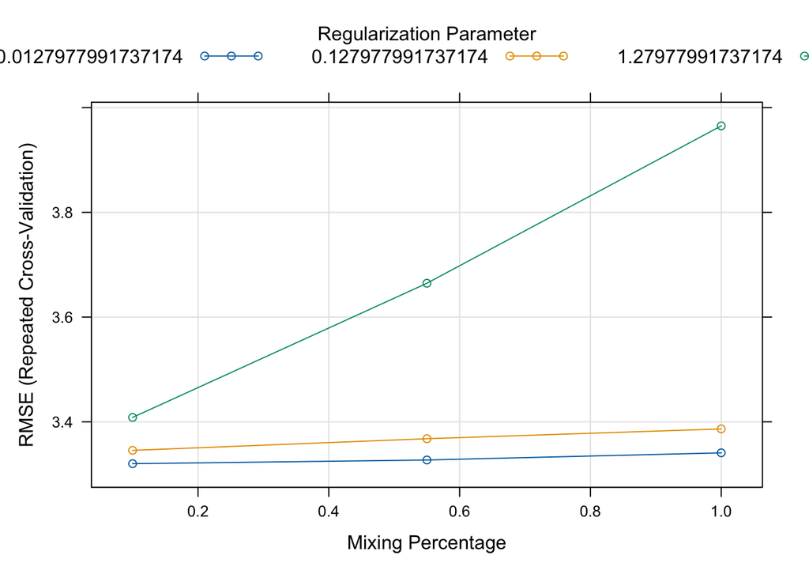

```r
plot(glmnet.fit)
```

### KNN

```r
prepare_data_for_knn <- function(data) {
  # Copy the dataset to avoid modifying the original
  data_processed <- data

  # Loop over each column
  for (col_name in names(data_processed)) {
    # Check if the column is not numeric
    if (!is.numeric(data_processed[[col_name]])) {
      # Attempt to convert to numeric
      numeric_column <- as.numeric(data_processed[[col_name]])

      # Check if the conversion was successful
      if (sum(!is.na(numeric_column)) > 0) {
        # Replace the column with the converted values
        data_processed[[col_name]] <- numeric_column
      } else {
        # Remove the column if it cannot be converted
        data_processed[[col_name]] <- NULL
      }
    }
  }

  return(data_processed)
}

# Using the function to remove all non numeric columns
life_processed <- prepare_data_for_knn(life_selected)
set.seed(1234)
model_knn1 <- train(Life.expectancy ~ ., data = life_processed,
                   trControl = trainControl(method = "cv", number = 5),
                   method = "knn",
                   tuneGrid = data.frame(k = 3:50),
                   metric = "RMSE")
print(model_knn1)
```

```
## k-Nearest Neighbors
##
## 1649 samples
##   19 predictor
##
## No pre-processing
## Resampling: Cross-Validated (5 fold)
## Summary of sample sizes: 1318, 1319, 1320, 1319, 1320
## Resampling results across tuning parameters:
##
##   k   RMSE      Rsquared    MAE
##    3  8.788310  0.11684215  6.649556
##    4  8.521155  0.13133102  6.475711
##    5  8.408692  0.13434778  6.497351
##    6  8.338130  0.13611849  6.466563
```

[output cut: 47 more lines]

```r
#  RMSE       Rsquared   MAE
#  8.228571  0.13715446  6.396723
```